# Conceptual Modesl to Types of Models

# Model Goals

- understanding
- prediction
- communication

You are doing this all the time - there are many reasons to make this process explicit (computer aided modeling)

# Conceptual Models

This is the **MOST** important step

- Models are simplifications of reality
- What processes in complex reality are your going to consider? why?
  - Inverse Inference - you think this mechanisms, parameter, input leads to the response you are observing (understanding)
  - You expect this process to be significantly influence outcome you are interested in (prediction)
  - You want to “show” what influences an observation/prediction (communication)
- Good question even for maching learning models - why?

# Conceptual Models

Things to think about

- What inputs/parameters will influence how a process/mechanism leads to the outputs you are interested in
- Can you measure those inputs/parameters? If not is there a proxy? Or another model?
- Are there features of the environment that influence the relationship between input/parameter and output?
- Are there inputs/parameters that you want to include to develop scenarios (things you’d want to ‘change’)
- Time and Space (are you looking at a short or long terms behavior? do you care about spatial patterns? at what scale?)

# In Class

- Form groups
- With your group, share your conceptual models that you thought about from Assignment 1;
- Pick one that is interesting to all 3 of you
- Discuss answers to soem of the questions above
- Sketch it

# Composing Diagrams

Pictorial representation your model and what needs to be included in the model to answer your questions (or achieve your modelling goal)

# Types of Model

There are many different ways to classify models

A *useful* classification looks at how models deal with space, time, and process

Useful because the *type* of model will have implications for how you *build* and *use/run* the model

# Stochastic - Deterministic

Stochastic: Model output is the probability of flood events of a magnitude greater than 500 m3/sec given rainfall probability distribution (artificial or generated from data) for a 100km2 watershed

Deterministic: Model output is the depth of flood given a rainfall event of 10cm over a 100km2 watershed

[source](http://www.vertex42.com/ExcelArticles/mc/MonteCarloSimulation.html)

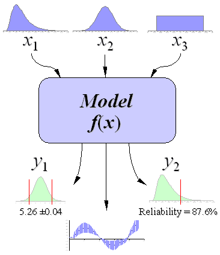

# Lumped …Spatially distributed

Lumped - single point in space, or space doesn’t matter

Spatially distributed - model is applied to different “patches” in space

- spatial units are independent
- spatial units interact with each other

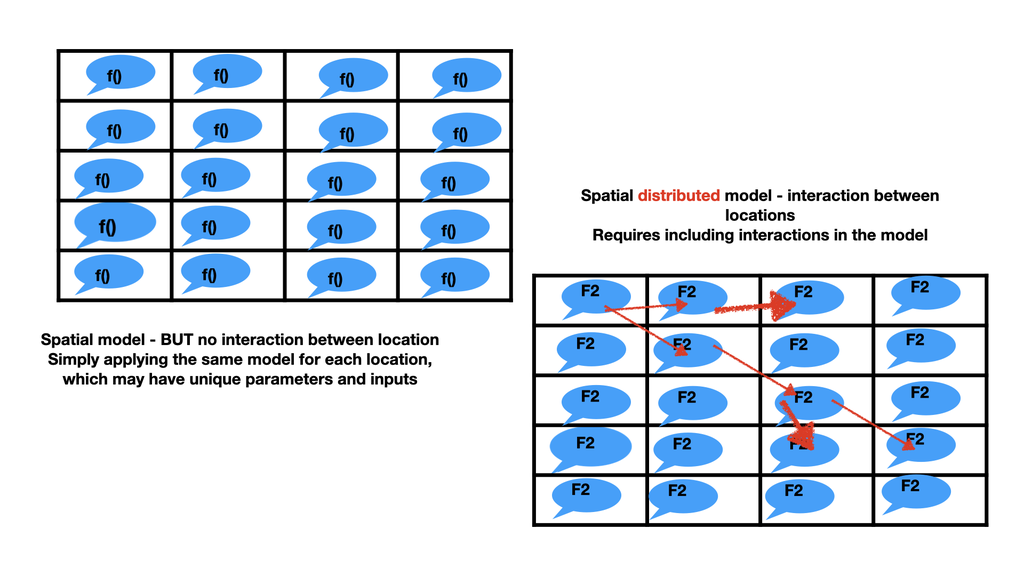

# climate models are good examples

[source](http://eo.ucar.edu/staff/rrussell/climate/modeling/climate_model_resolution.html)

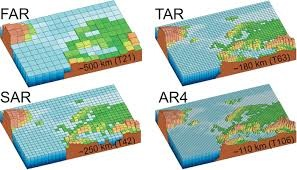

Resolution matters for spatial models

# Static- Dynamic Time Varying

Static - Processes or Variables modeled do not evolve with time

Dynamic - model elements evolve through time - and variables/results at one time step typically depends on previous time step

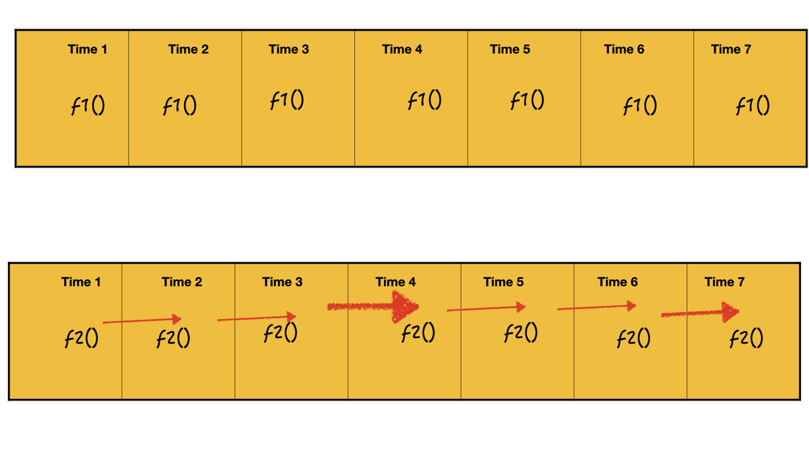

# Example of a time varying (dynamic) model

Modeling disease through time

[source](http://www.econometricsbysimulation.com/2013/05/sir-model-flue-season-dynamic.html)

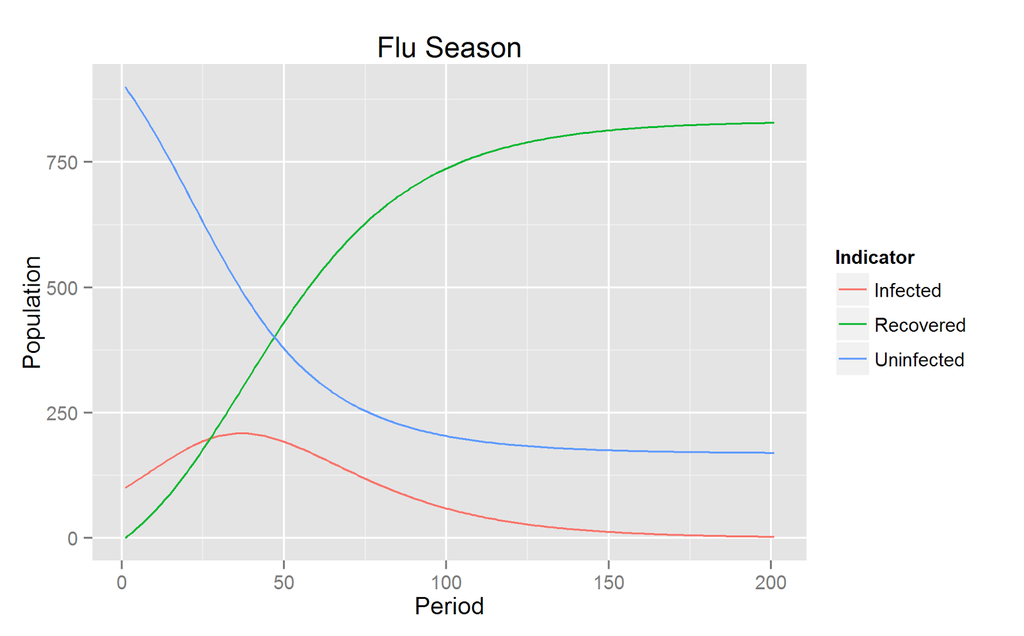

# Abstract - Physically/Process based

Abstract - relationship between inputs and output depends on parameters that don’t necessarily have a physical meaning - machine learning models are good examples

Physically based - parameters do have a physical meaning (could be measured) - relationships derived from first principles (theory) of how things work

Think…simple bucket model

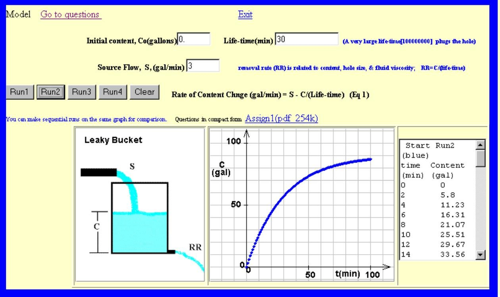

# Basic components of models

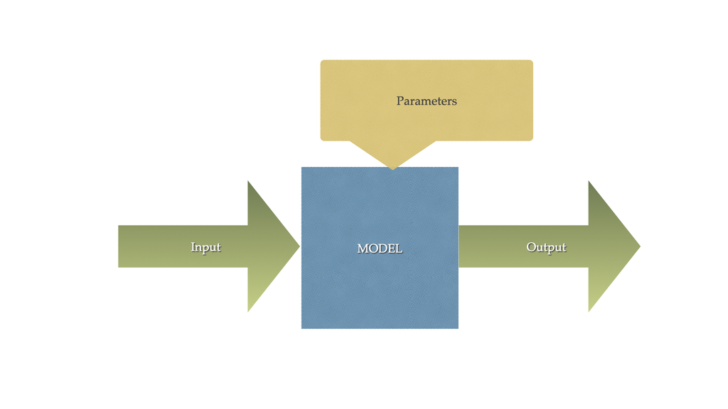

# How to start

- What are your inputs-outputs
- What’s in the box (the model itself) that gives you a relationship between outputs and inputs
- Transfer function
- Parameters, values that influences how the model relationships work

# Types of Models

Conceptual………….Mathematical

Stochastic………….Deterministic

Lumped………….Spatially Distributed: *SPACE*

Static………….Dynamic : *TIME*

Abstract………….Physically/Process Based

but biggest differences may often be the degree specific processes/parameters are accounted for

# Types of models: Example

- Input: Reservoir height (height) and flow rate (flow)
- Output: Instantaneous power generation (W/s)
- Parameter: Reservoir Efficiency (K)

Conceptual model

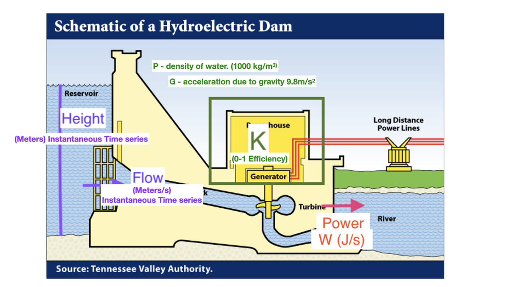

# Types of models: Example

- **Input**: Reservoir height and flow rate
- **Output**: Instantaneous power generation (W/s)
- **Parameters**: K Efficiency , ρ (density of water), g (acceleration due to gravity)

P = ρ * h * r * g * K Efficiency;

- P is Power in watts,
- ρ is the density of water (~1000 kg/m3)
- h is height in meters,
- r is flow rate in cubic meters per second,
- g is acceleration due to gravity of 9.8 m/s2,
- K Efficiency is a coefficient of efficiency ranging from 0 to 1.

This is a static (one point in time), deterministic, lumped (one place) model; its more or less physically based

# Types of models: Example

If we expand the model to output power production over a year, where inputs were streamflow for each day into the reservoir - *Dynamic Model*

If we expand to model power production from all the reservoirs in California, accounting for spatial patterns of snowmelt inputs and upstream-downstream relationships - *Spatially Distributed Model*

If we modified the model to estimate the probability distribution of power production, given a probability distribution of reservoir levels - *Stochastic Model*

# STEPS: Modeling for Problem Solving in ES

- Clearly define your goal (question you want to answer, hypothesis you want to test, prediction you want to make) - as precisely as possible
- Develop a conceptual model - draw it, think about what type of model it is!
- Design or Select your model
- Implement the model
- Evaluate the model and quantify uncertainty
- Apply the model to the goal
- Communicate model results

# Design and Implement Step

- Translate conceptual model into functions (a single box or set of connected boxes)
  - useful to diagram this (flow chart)
- Define inputs (data type, units)
- Define output (data type, units)
- Define model structure (mathematical representation of transfer functions)
- Choose programming language
- Write model
- Document the model (meta data)
- Test model

# Coding Concepts

- Any questions?

Learn by example

- Pay attention to the *documentation* and *syntax* of **compute_diversity.R**

# ASSIGNMENT 2 Almond Yields

Lobell et al., 2006 used data to build models of tree crop yield for California that captured how climate variation (place and time) might influence yield

- Yield anomaly
- Climate variables

Assumptions…as you work think about what these are…

# Assignment

For this assignment you will work in *pairs*

Your goal is to implement a simple model of almond yield anomaly response to climate

- Inputs: daily times series of minimum, maximum daily temperatures and precipitation
- Outputs: maximum, minimum and mean yield anomoly for a input time series

The Lobell et al. 2006 paper will be the source for the transfer function that you will use in your model; specifically look at the equations in table 2.

# What you will do - Model Set Up

1. Draw diagram to represent your model - how it will translate inputs to outputs, with parameters that shape the relationship between inputs an outputs - on your diagram list what your inputs, parameters and outputs are with units
2. Implement your diagram as an R function

Here are some ideas to think though. The climate data is going to need to be processed (e.g note that the model uses climate data from a particular month - you have ALL of the climate as daily data). Here are two possible model outlines to follow

● Almond_model <- function(clim_var1, clim_var2, parameters){……}

● Almond_model <- function(clim, parameters){……}

The first example is where the climate variables are separately input into the function - climate data is processed beforehand as part of model set up

The second is where a climate data frame is the input in the function and you extract the useful data from it as part of the model.

You can pick which option you prefer (or try both)

# Run the model

3. Run your model for the **clim.txt** data that is posted on Canvas,

**clim.txt** has the following columns

these 4 columns tell you when climate observations were made

- *day*
- *month*
- *year*
- *wy* (water year)

the next 3 columns are the climate observations

- maximum (*tmax_c*) daily temperature
- minimum (*tmin_c*) daily temperature
- precipitation (*precip*) on that day in mm

# check your work

I will tell you that

- the maximum almond yield anomaly should be approximately 1920 ton/acre
- the lowest almond yield anomaly should be approximately -0.027 ton/acre
- the mean almond yield anomaly should be approximately 182 ton/acre

# Notes

We will build on this in next Thursday’s class

- There are always multiple ways to code something in R;
- Remember that we want to strive for our code being as simple and streamline as possible.
- Style counts.
  - Make sure you choose meaningful variable names and add comments.
  - Include comments at the top of the function to tell the user what the inputs/outputs are and their units and format.

# What to hand in on Canvas

Two separate files (or a link to a repository with these files)

1. a R file that has your function definition
2. a Rmarkdown file that includes your conceptual model (embed as picture) and shows how you applied the function to the test climate data (*clim.txt*)

# Grading Rubric

Conceptual model (20 pts)

- a clear diagram that corresponds with your R function (10 pts)
- inputs and output and parameters shown on the diagram (10 pts)

R Implementation (30 pts)

- correct function implementation (*.R file) (10 pts)
- application of the function to **clim.txt** (in Rmarkdown file) (10 pts)
- coding practices (clear documentation, informative variables names) (10 pts)